# 1. Оценить тип математического распределения представленных значений: бимодальное.

# 2.2 Categories + Gaussian

# Суть метода Elliptic Envelope заключается в разделении выборки на принадлежащие нормальному распределению и на "аномалии". Чем ближе начальное распределение признака к нормальному, тем более эффективно будет работать данный алгоритм

```python
df_class0 = df.loc[df['categories'] == 0, ['max_slow']]
df_class1 = df.loc[df['categories'] == 1, ['max_slow']]
df_class2 = df.loc[df['categories'] == 2, ['max_slow']]
df_class3 = df.loc[df['categories'] == 3, ['max_slow']]


# 0 -  label='Выходной (Ночь)
# 1 - label ='Выходной (Дневное время)
# 2 - label ='Будний день (Ночь)
# 3 - label ='Будний день (Дневное время)

# fig, axs = plt.subplots(2,2)
# df_class0.hist(ax=axs[0,0],bins=32)
# df_class1.hist(ax=axs[0,1],bins=32)
# df_class2.hist(ax=axs[1,0],bins=32)
# df_class3.hist(ax=axs[1,1],bins=32)
# rcParams['figure.figsize'] = 14,8
```

```python
# An estimation of anomly population of the dataset (necessary for several algorithm)
outliers_fraction = 0.004

# applying ellipticEnvelope(gaussian distribution) at each categories

envelope =  EllipticEnvelope(contamination = outliers_fraction)
X_train = df_class0.values.reshape(-1,1)
envelope.fit(X_train)
df_class0 = pd.DataFrame(df_class0)
df_class0['deviation'] = envelope.decision_function(X_train)
df_class0['anomaly'] = envelope.predict(X_train)

# applying ellipticEnvelope(gaussian distribution) at each categories
envelope =  EllipticEnvelope(contamination = outliers_fraction)
X_train = df_class1.values.reshape(-1,1)
envelope.fit(X_train)

df_class1 = pd.DataFrame(df_class1)
df_class1['deviation'] = envelope.decision_function(X_train)
df_class1['anomaly'] = envelope.predict(X_train)

# applying ellipticEnvelope(gaussian distribution) at each categories
envelope =  EllipticEnvelope(contamination = outliers_fraction)
X_train = df_class2.values.reshape(-1,1)
envelope.fit(X_train)

df_class2 = pd.DataFrame(df_class2)
df_class2['deviation'] = envelope.decision_function(X_train)
df_class2['anomaly'] = envelope.predict(X_train)

# applying ellipticEnvelope(gaussian distribution) at each categories
envelope =  EllipticEnvelope(contamination = outliers_fraction)
X_train = df_class3.values.reshape(-1,1)
envelope.fit(X_train)

df_class3 = pd.DataFrame(df_class3)
df_class3['deviation'] = envelope.decision_function(X_train)
df_class3['anomaly'] = envelope.predict(X_train)
```

```python
a0 = df_class0.loc[df_class0['anomaly'] == 1, 'max_slow']
b0 = df_class0.loc[df_class0['anomaly'] == -1, 'max_slow']

a1 = df_class1.loc[df_class1['anomaly'] == 1, 'max_slow']
b1 = df_class1.loc[df_class1['anomaly'] == -1, 'max_slow']

a2 = df_class2.loc[df_class2['anomaly'] == 1, 'max_slow']
b2 = df_class2.loc[df_class2['anomaly'] == -1, 'max_slow']

a3 = df_class3.loc[df_class3['anomaly'] == 1, 'max_slow']
b3 = df_class3.loc[df_class3['anomaly'] == -1, 'max_slow']
```

# Отчётливо видно, как модель отсекает наблюдения с наименьшим и наибольшим количеством дбА, расценивая их как аномалии

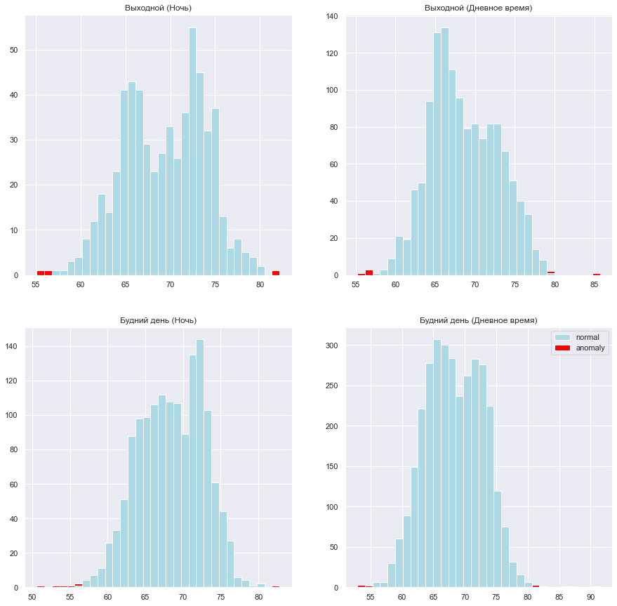

```python
fig, axs = plt.subplots(2,2)
axs[0,0].hist([a0,b0], bins=32, stacked=True, color=['lightblue', 'red'], label=['normal', 'anomaly'])
axs[0,1].hist([a1,b1], bins=32, stacked=True, color=['lightblue', 'red'], label=['normal', 'anomaly'])
axs[1,0].hist([a2,b2], bins=32, stacked=True, color=['lightblue', 'red'], label=['normal', 'anomaly'])
axs[1,1].hist([a3,b3], bins=32, stacked=True, color=['lightblue', 'red'], label=['normal', 'anomaly'])
axs[0,0].set_title("Выходной (Ночь)")
axs[0,1].set_title("Выходной (Дневное время)")
axs[1,0].set_title("Будний день (Ночь)")
axs[1,1].set_title("Будний день (Дневное время)")
plt.legend()
plt.show()
rcParams['figure.figsize'] = 15,13
```

# У данной модели интуитивно гораздо более понятный подход к выявлению отклонений - даже визуально видно, что она отбирает в качестве аномалий локальные экстремумы

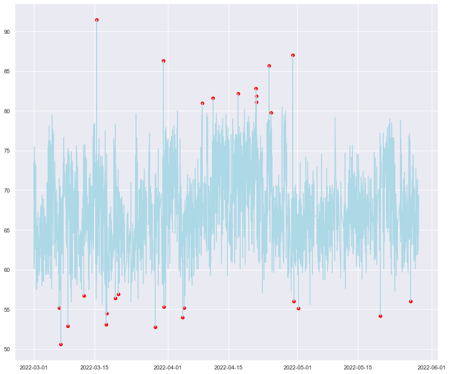

```python
# add the data to the main
df_class = pd.concat([df_class0, df_class1, df_class2, df_class3])
df['anomaly22'] = df_class['anomaly']
df['anomaly22'] = np.array(df['anomaly22'] == -1).astype(int)

fig, ax = plt.subplots()

a = df.loc[df['anomaly22'] == 1, ('timestamp', 'max_slow')] #anomaly

ax.plot(df['timestamp'], df['max_slow'], color='lightblue')
ax.scatter(a['timestamp'],a['max_slow'], color='red')
plt.show()
```

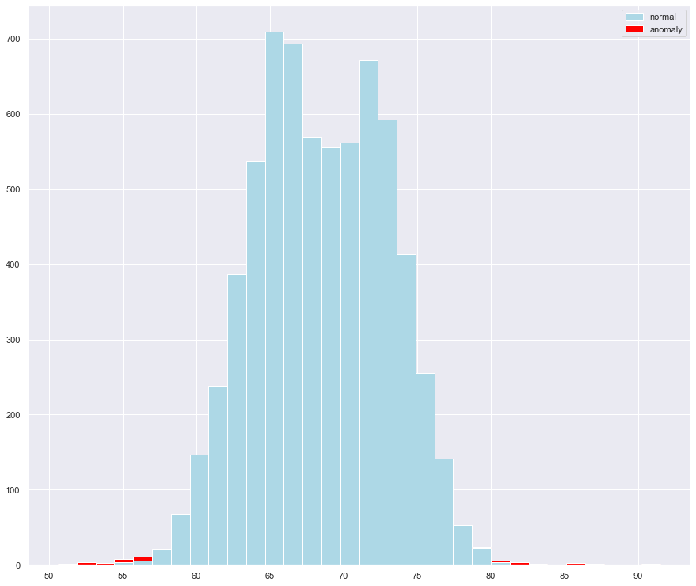

```python
a = df.loc[df['anomaly22'] == 0, 'max_slow']
b = df.loc[df['anomaly22'] == 1, 'max_slow']

fig, axs = plt.subplots()
axs.hist([a,b], bins=32, stacked=True, color=['lightblue', 'red'], label=['normal', 'anomaly'])
plt.legend()
rcParams['figure.figsize'] = 15,8
plt.show()
```

# Какие наблюдения были выбраны моделью 2.2 в качестве статистических аномалий:

```python
df.loc[df['anomaly22'] == 1].head()
```

|  | timestamp | max_slow | type | model | month | hours | daylight | DayOfTheWeek | WeekDay | time_epoch | categories | cluster | principal_feature1 | principal_feature2 | anomaly | anomaly22 |
| --- | --- | --- | --- | --- | --- | --- | --- | --- | --- | --- | --- | --- | --- | --- | --- | --- |
| 577 | 2022-03-06 19:33:26 | 55.2 | 16 | Boeing 737-800 | Март | 19 | 1 | 6 | 0 | 16465952 | 1 | 8 | 1.241163 | -1.220684 | 0 | 1 |
| 627 | 2022-03-07 06:03:11 | 50.6 | 16 | Boeing 737-800 | Март | 6 | 0 | 0 | 1 | 16466329 | 2 | 15 | -1.510394 | 0.842608 | 0 | 1 |
| 764 | 2022-03-08 21:20:43 | 52.9 | 9 | Airbus A330-300 | Март | 21 | 1 | 1 | 1 | 16467744 | 3 | 7 | -1.250959 | -1.248051 | 0 | 1 |
| 1109 | 2022-03-12 12:37:23 | 56.7 | 16 | Boeing 737-800 | Март | 12 | 1 | 5 | 0 | 16470886 | 1 | 1 | 1.010364 | -0.657236 | 0 | 1 |
| 1356 | 2022-03-15 11:59:12 | 91.5 | 5 | Airbus A319 | Март | 11 | 1 | 1 | 1 | 16473455 | 3 | 9 | -0.733430 | 0.577758 | 0 | 1 |

# 2.3 Isolation Forest

```python
# An estimation of anomly population of the dataset (necessary for several algorithm)
outliers_fraction = 0.004

# Take useful feature and standardize them
data = df[['max_slow', 'hours', 'daylight', 'DayOfTheWeek', 'WeekDay', 'type']]
min_max_scaler = preprocessing.StandardScaler()
np_scaled = min_max_scaler.fit_transform(data)
data = pd.DataFrame(np_scaled)

# train isolation forest
model =  IsolationForest(contamination = outliers_fraction)
model.fit(data)

# add the data to the main
df['anomaly23'] = pd.Series(model.predict(data))
df['anomaly23'] = df['anomaly23'].map( {1: 0, -1: 1} )
print(df['anomaly23'].value_counts())
```

```
0    6646
1      27
Name: anomaly23, dtype: int64
```

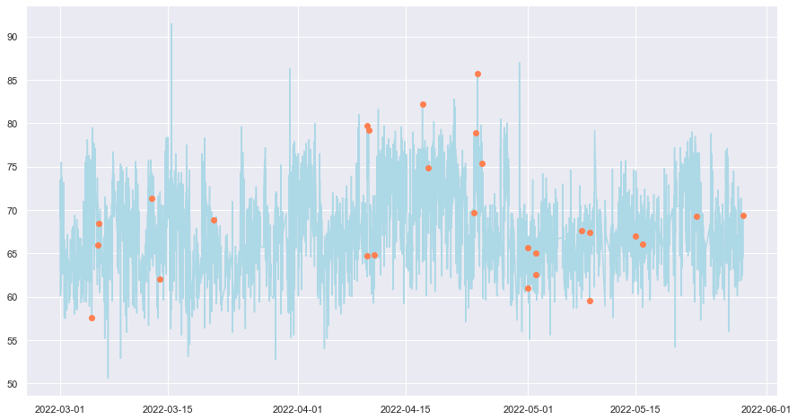

```python
fig, ax = plt.subplots()

a = df.loc[df['anomaly23'] == 1, ['timestamp', 'max_slow']] #anomaly

ax.plot(df['timestamp'], df['max_slow'], color='lightblue')
ax.scatter(a['timestamp'],a['max_slow'], color='coral', zorder=3)
plt.show()
```

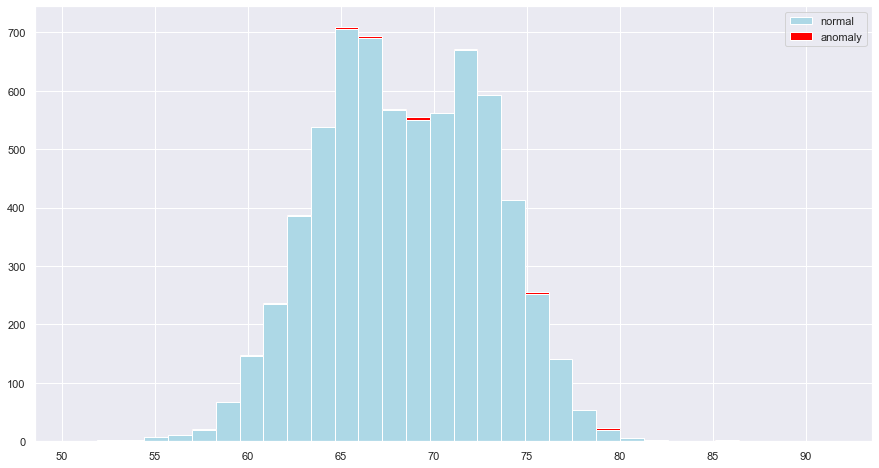

```python
a = df.loc[df['anomaly23'] == 0, 'max_slow']
b = df.loc[df['anomaly23'] == 1, 'max_slow']

fig, axs = plt.subplots()
axs.hist([a,b], bins=32, stacked=True, color=['lightblue', 'red'], label=['normal', 'anomaly'])
plt.legend()
rcParams['figure.figsize'] = 15,10
plt.show()
```

# Очевидна разница в подходах между Elliptic envelope, Isolation Forest. Если для Гауссовского распределения аномалиями классифицировались хвосты распределения, то Isolation Forest фокусируется в том числе и на значениях, находящихся ближе к средним значениям. Затрудняюсь интерпретировать результаты того, почему имено эти наблюдения были выбраны в качестве аномалий.

# Какие наблюдения были выбраны моделью 2.3 в качестве статистических аномалий:

```python
df.loc[df['anomaly23'] == 1].head()
```

|  | timestamp | max_slow | type | model | month | hours | daylight | DayOfTheWeek | WeekDay | time_epoch | categories | cluster | principal_feature1 | principal_feature2 | anomaly | anomaly22 | anomaly23 |
| --- | --- | --- | --- | --- | --- | --- | --- | --- | --- | --- | --- | --- | --- | --- | --- | --- | --- |
| 437 | 2022-03-05 03:21:32 | 57.6 | 44 | Sukhoi Superjet 100-95 | Март | 3 | 0 | 5 | 0 | 16464504 | 0 | 10 | 1.067901 | 0.768548 | 0 | 0 | 1 |
| 513 | 2022-03-05 23:12:47 | 66.0 | 40 | British Aerospace 125 series | Март | 23 | 0 | 5 | 0 | 16465219 | 0 | 1 | 1.141146 | -0.407838 | 0 | 0 | 1 |
| 518 | 2022-03-05 23:49:30 | 68.5 | 45 | Tupolev Tu-204 | Март | 23 | 0 | 5 | 0 | 16465241 | 0 | 1 | 1.179369 | -0.412206 | 0 | 0 | 1 |
| 1155 | 2022-03-12 23:47:26 | 71.3 | 44 | Sukhoi Superjet 100-95 | Март | 23 | 0 | 5 | 0 | 16471288 | 0 | 12 | 1.214957 | -0.322537 | 0 | 0 | 1 |
| 1220 | 2022-03-13 23:50:34 | 62.0 | 31 | Embraer Legacy 600 | Март | 23 | 0 | 6 | 0 | 16472154 | 0 | 1 | 1.340694 | -0.398704 | 0 | 0 | 1 |

# 2.4 One class SVM

# Основная идея алгоритма (в случае с классификацией) — разделить классы гиперплоскостью так, чтобы максимизировать расстояние (зазор) между ними.

```python
data = df[['max_slow', 'hours', 'daylight', 'DayOfTheWeek', 'WeekDay', 'type']]
min_max_scaler = preprocessing.StandardScaler()
np_scaled = min_max_scaler.fit_transform(data)
# train one class SVM
model =  OneClassSVM(nu=0.95 * outliers_fraction) #nu=0.95 * outliers_fraction  + 0.05
data = pd.DataFrame(np_scaled)
model.fit(data)
# add the data to the main
df['anomaly24'] = pd.Series(model.predict(data))
df['anomaly24'] = df['anomaly24'].map( {1: 0, -1: 1} )
print(df['anomaly24'].value_counts())
```

```
0    6637
1      36
Name: anomaly24, dtype: int64
```

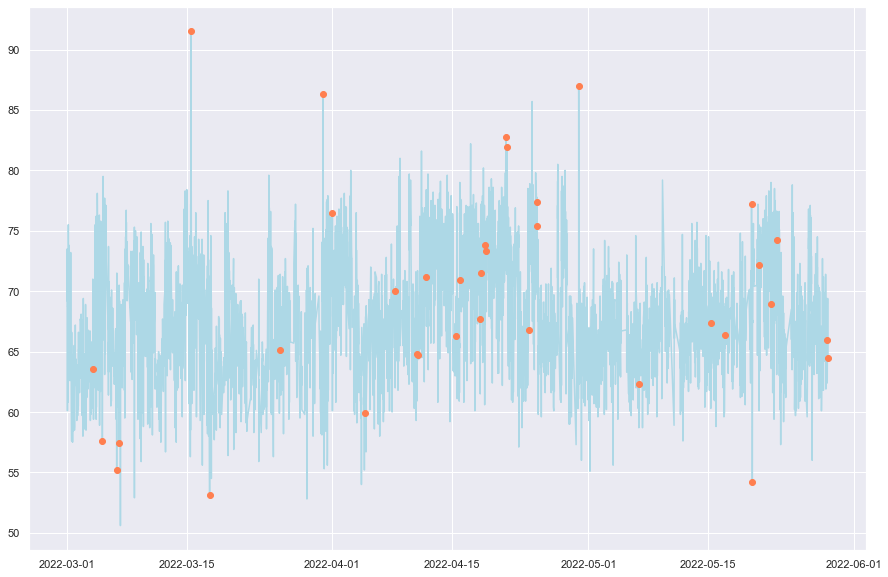

```python
fig, ax = plt.subplots()

a = df.loc[df['anomaly24'] == 1, ['timestamp', 'max_slow']] #anomaly

ax.plot(df['timestamp'], df['max_slow'], color='lightblue')
ax.scatter(a['timestamp'],a['max_slow'], color='coral', zorder=3)
plt.show()
```

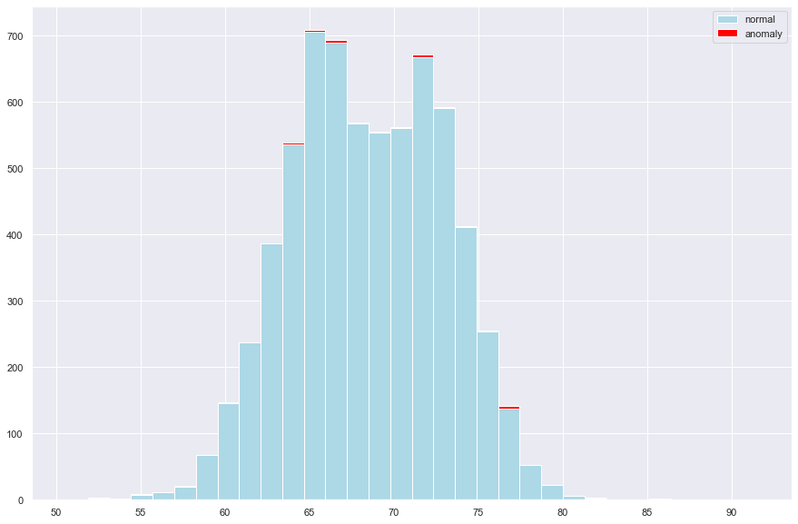

```python
a = df.loc[df['anomaly24'] == 0, 'max_slow']
b = df.loc[df['anomaly24'] == 1, 'max_slow']

fig, axs = plt.subplots()
axs.hist([a,b], bins=32, stacked=True, color=['lightblue', 'red'], label=['normal', 'anomaly'])
plt.legend()
plt.show()
```

# Результат схож с Isolation Forest. Обе модели акцентируют внимание на аномалиях среди значений, близким к средним по ген. совокупности.

```python
df_24 = df.loc[df['anomaly24'] == 1]
df_23 = df.loc[df['anomaly23'] == 1]
df_22 = df.loc[df['anomaly22'] == 1]
df_21 = df.loc[df['anomaly'] == 1]
```

```python
elements_in_all = list(set.intersection(*map(set, [df_23.index, df_24.index])))
elements_in_all
```

```
[4426, 437, 2975]
```

```python
elements_in_all1 = list(set.intersection(*map(set, [df_21.index, df_22.index])))
elements_in_all1
```

```
[]
```

# Итог: в качестве BASE LINE я бы стал использовать модель 2.2. Elliptic Envelope, отсекающую хвосты распределения признака. С точки зрения интерпретации результатов модели, данная модель - самая понятная. Она убирает экстремально низкие и экстремально высокие значения. Все остальные модели слабо интерпретируемы.

# III. Cредние уровни шума для каждой модели самолета, встречающейся в выборке более 100 раз.

# Функция определения среднего значения уровня звука

```python
def dba_mean(series):

    series.sort_values(ascending=False)

    if series.max() - series.min() < 7:
        return series.mean()

    else:
        return reduce(lambda x, y: 10*math.log10(10**(x*0.1)+ 10**(y*0.1)), series) - 10 * math.log10(series.shape[0])
```

# В приведенной таблице среднее значение уровня шума приведено под наименованием dba_mean (cр. арифм, мода приведены для сравнения)

```python
# dba_mean - расчёт среднего значения уровня звука по формуле с логарифмом. ср. арифм и медиана приведены для сравнения
planes_mean_db_stat = df.groupby(['model']).agg({'max_slow': [dba_mean, 'mean', statistics.mode, 'count']}).sort_values(by = [('max_slow', 'count')], ascending=False)
planes_mean_db_stat.columns = planes_mean_db_stat.columns.droplevel()
planes_mean_db_stat.query('count > 100')
```

| model | dba_mean | mean | mode | count |
| --- | --- | --- | --- | --- |
| Boeing 737-800 | 71.201899 | 69.612294 | 72.3 | 2668 |
| Sukhoi Superjet 100-95 | 70.842073 | 68.588129 | 66.6 | 834 |
| Boeing 737-500 | 70.563179 | 68.661970 | 69.3 | 660 |
| Airbus A319 | 69.808104 | 66.286325 | 64.9 | 351 |
| Airbus A320 | 69.115650 | 67.010660 | 65.5 | 197 |
| Airbus A321 | 72.001370 | 70.120305 | 63.9 | 197 |
| Airbus A330-200 | 73.428814 | 71.274194 | 70.3 | 186 |
| Embraer Legacy 600 | 64.149362 | 62.805525 | 61.6 | 181 |
| Boeing 767-200 | 71.634736 | 69.701899 | 67.2 | 158 |
| Canadair Regional Jet 200 | 64.975432 | 62.651471 | 61.6 | 136 |
| Boeing 737-400 | 71.577462 | 69.158209 | 67.4 | 134 |
| Tupolev Tu-204 | 69.604729 | 67.855970 | 65.7 | 134 |
| Boeing 737-700 | 69.509565 | 67.867826 | 67.8 | 115 |
| Boeing 757-200 | 69.277726 | 67.487611 | 67.1 | 113 |